# Laboratorio 2 - Análisis de Datos

## Laboratorio N° 2

### Juan Carlos López

#### “Intensidad de la Luz”

Trabajaremos con una base de datos real, esta corresponde a una curva de luz (intensidad de luz de una estrella en función del tiempo). En primer lugar, lea el archivo ts.csv utilizando pandas. Trabaje con una muestra de 200 datos.

[output not shown]

```python
#SETUP
import pandas as pd
import numpy as np
import joblib
from sklearn.linear_model import ElasticNet
from sklearn.model_selection import train_test_split
from sklearn.metrics import mean_squared_error, root_mean_squared_error
from sklearn.preprocessing import PolynomialFeatures
from sklearn.linear_model import LinearRegression
import warnings
#Para los gráficos
import matplotlib.pyplot as plt

warnings.filterwarnings('ignore')

plt.rc('font', size=14)
plt.rc('axes', labelsize=14, titlesize=14)
plt.rc('legend', fontsize=14)
plt.rc('xtick', labelsize=10)
plt.rc('ytick', labelsize=10)
```

```python
#1
df_luz = pd.read_csv("ts.csv")
df_luz_prueba = df_luz.sample(n=200,random_state=365)
X = df_luz_prueba['tiempo'].values.reshape(-1,1)
y = df_luz_prueba['magnitud'].values.reshape(-1,1)
```

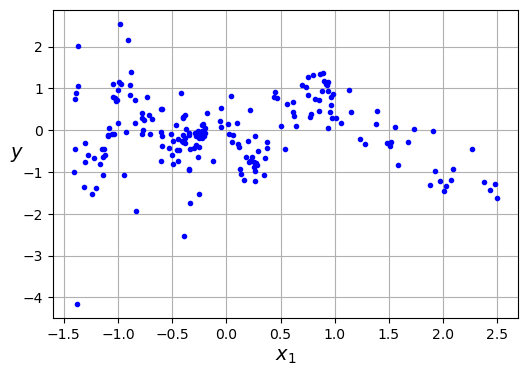

```python
plt.figure(figsize=(6, 4))
plt.plot(X, y, "b.")
plt.xlabel("$x_1$")
plt.ylabel("$y$", rotation=0)
#plt.axis([-3, 3, -3, 3])
plt.grid()
#save_fig("quadratic_data_plot")
plt.show()
```

```python
poly_features = PolynomialFeatures(degree=3, include_bias=False)
X_poly = poly_features.fit_transform(X)

lin_reg = LinearRegression()
lin_reg.fit(X_poly, y)
print(lin_reg.intercept_)
print(lin_reg.coef_)

X_new = np.linspace(-3, 3, 100).reshape(100, 1)
X_new_poly = poly_features.transform(X_new)
y_new = lin_reg.predict(X_new_poly)
```

```
[-0.01677617]
[[ 0.41339544  0.064398   -0.20657808]]
```

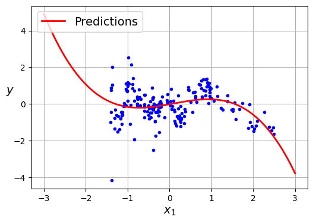

```python
plt.figure(figsize=(6, 4))
plt.plot(X, y, "b.")
plt.plot(X_new, y_new, "r-", linewidth=2, label="Predictions")
plt.xlabel("$x_1$")
plt.ylabel("$y$", rotation=0)
plt.legend(loc="upper left")
#plt.axis([-3, 3, 0, 10])
plt.grid()
#save_fig("quadratic_predictions_plot")
plt.show()
```

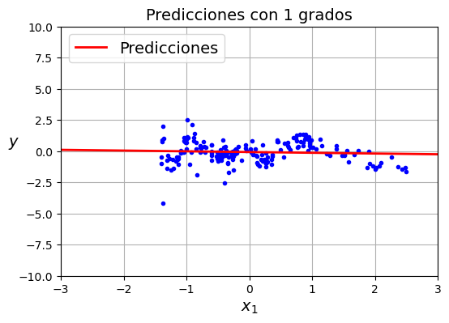

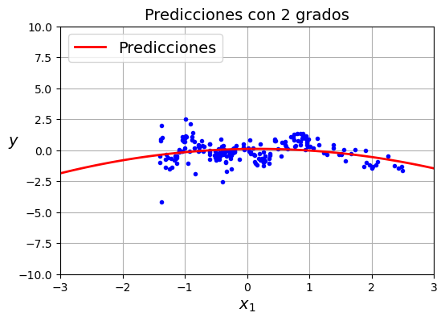

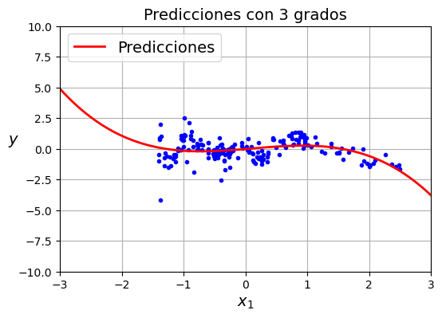

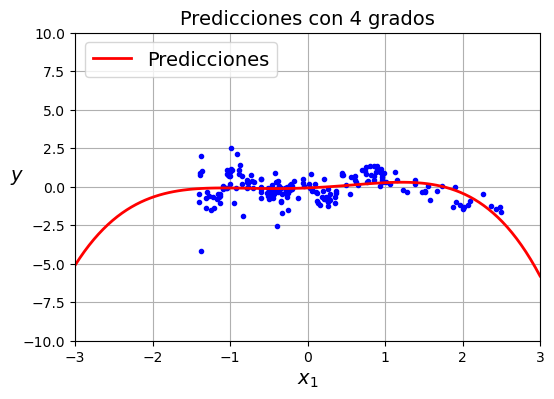

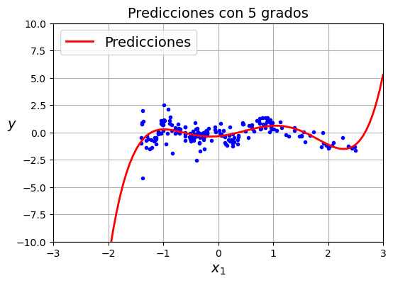

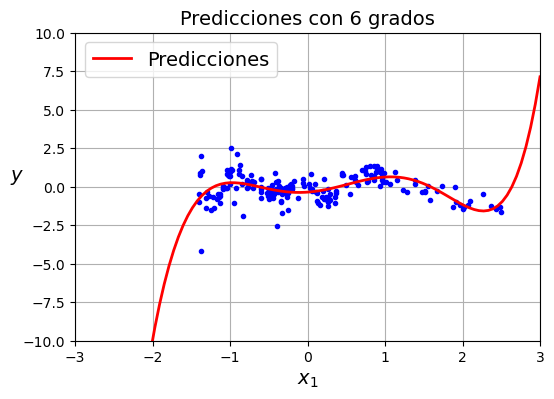

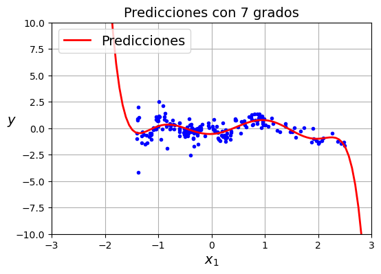

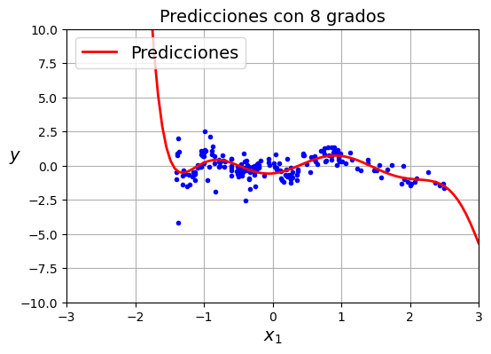

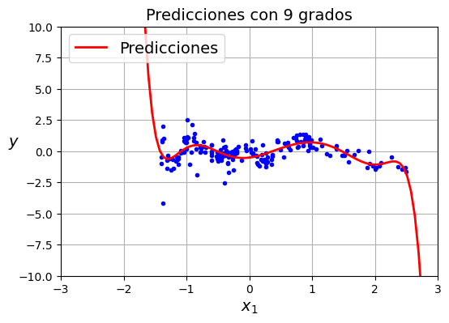

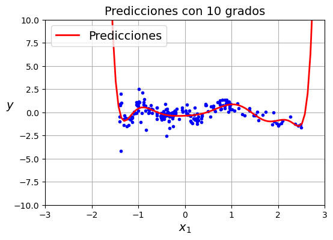

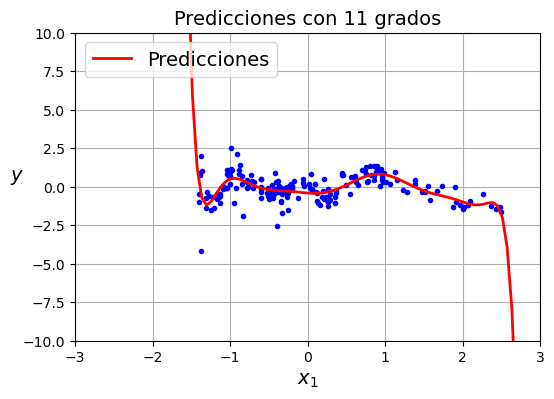

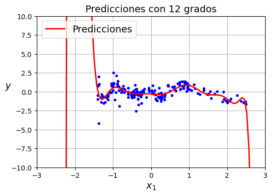

[3 more figures not shown]

```python
for i in range(15):
    poly_features = PolynomialFeatures(degree=i+1, include_bias=False)
    X_poly = poly_features.fit_transform(X)

    lin_reg = LinearRegression()
    lin_reg.fit(X_poly, y)

    X_new = np.linspace(-3, 3, 100).reshape(100, 1)
    X_new_poly = poly_features.transform(X_new)
    y_new = lin_reg.predict(X_new_poly)

    plt.figure(figsize=(6, 4))
    plt.title(f"Predicciones con {i+1} grados")
    plt.plot(X, y, "b.")
    plt.plot(X_new, y_new, "r-", linewidth=2, label="Predicciones")
    plt.xlabel("$x_1$")
    plt.ylabel("$y$", rotation=0)
    plt.legend(loc="upper left")
    plt.axis([-3, 3, -10, 10])
    plt.grid()
    #save_fig("quadratic_predictions_plot")
    plt.show()
```

A medida que se avanza en los grados, la curva generada se ajusta mejor a los puntos de la muestra, pero en los extremos se pierde, por lo que a mayor grados hay un overfitting. De acuerdo a los gráficos, podria decir que un polinomio de 3 grados, podriamos obtener mejores predicciones.

## Determinando el % grasa Corporal

Este set de datos enumera en su variable objetivo estimaciones del porcentaje de grasa corporal determinado mediante pesaje bajo el agua y varias mediciones de circunferencia corporal para 252 personas. Las variables que se enumeran a continuación, de izquierda a derecha, son:

```
• Densidad corporal a partir de la ecuación de Siri (1956),
• Edad (años),
• Peso (libras),
• Altura (pulgadas),
• Circunferencia del cuello (cm),
• Circunferencia del pecho (cm),
• Circunferencia del abdomen (cm),
• Circunferencia de la cadera (cm),
• Circunferencia del muslo (cm),
• Circunferencia de la rodilla (cm),
• Circunferencia del tobillo (cm),
• Circunferencia del bíceps (extendido) (cm),
• Circunferencia del antebrazo (cm) y
• Circunferencia de la muñeca (cm)
```

A continuación, vamos a explorar distintos modelos polinómicos para explicar el % de grasa corporal a partir del set de datos restante. Para ello, diseñe una rutina que encuentre los hiperparámetros para el mejor modelo considerando los siguientes aspectos:

```
• Experimente la regularización Ridge y Lasso con 6 alphas distintos para cada uno.
• Aplique ElasticNet con un r:0,5 y compare los resultados usando r:0.25 y r:0.75.
```

Una vez determinado el mejor modelo de regresión polinomial que explique el % de grasa corporal, simule el modelo con al menos 3 datos nuevos distintos.

Finalmente exporte el mejor modelo encontrado usando pickle o joblib.

```python
from sklearn.datasets import fetch_openml
df = fetch_openml('bodyfat')
X, y = df.data, df.target
X = X.drop('Density', axis=1)
```

```python
parametros = {
    "alphas":[0.001,0.01,0.1,0,1,10],
    "ratio":[0,0.25,0.5,0.75,1]
}
```

```python
X_train, X_test, y_train, y_test = train_test_split(X, y, test_size=0.3, random_state=42)

mejor_mse = float('inf')
mejor_modelo = None
mejores_parametros = {}

for a in parametros["alphas"]:
    for r in parametros["ratio"]:
        elastic_net = ElasticNet(alpha=a, l1_ratio=r, random_state = 42)
        elastic_net.fit(X_train, y_train)

        # Predecir en el conjunto de prueba
        y_pred = elastic_net.predict(X_test)

        # Calcular el MSE
        mse = mean_squared_error(y_test, y_pred)

        # Verificar si es el mejor modelo
        if mse < mejor_mse:
            mejor_mse = mse
            mejor_modelo = elastic_net
            mejores_parametros = {"alpha": a, "l1_ratio": r}

# Resultados
print(f"Mejor MSE: {mejor_mse:.4f}")
print(f"Mejores parámetros: {mejores_parametros}")
```

```
Mejor MSE: 19.9298
Mejores parámetros: {'alpha': 0, 'l1_ratio': 0}
```

```python
mejor_modelo
```

```
ElasticNet(alpha=0, l1_ratio=0, random_state=42)
```

```python
# Matriz de nuevos datos a predecir
X_nuevo = [[36,198,66.9291,36.2,93.1,95.2,94.5,55.0,36.3,23.9,35.0,24.4,18.1],
          [47,160,55.9291,26.2,83.1,85.2,90.5,60.0,20.3,15.9,33.0,26.4,20.1],
          [15,170,50.9291,25.2,70.1,70.2,70.5,60.0,20.3,23.9,33.0,15.4,15.1]]
```

```python
y_nuevo = mejor_modelo.predict(X_nuevo)
print("Predicciones:", y_nuevo)
```

```
Predicciones: [21.07025758 16.68096413 10.07822038]
```

```python
# Guardo el mejor modelo obtenido anteriormente
joblib.dump(mejor_modelo, "mejor_modelo.pkl")

# Cargo el modelo en una nueva variable
modelo_cargado = joblib.load("mejor_modelo.pkl")

# Realizo predicciones con el modelo cargado (Usando la matriz anterior)
nuevas_predicciones = modelo_cargado.predict(X_nuevo)
print("Predicciones con el modelo cargado:", nuevas_predicciones)
```

```
Predicciones con el modelo cargado: [21.07025758 16.68096413 10.07822038]
```